# Indicator Heterogeneity I: Temporal Heterogeneity

Addison

```r
PARCOMPUTE = TRUE
N_CORE = parallel::detectCores()
```

# Background

This notebook builds off `01_introduction.Rmd`, which introduced and motivated the problem of heterogeneity, and then examined spatial heterogeneity in the DV signal, ignoring the possibility of temporal heterogeneity (i.e., in the *sensorization* step, data was aggregated across all of time. In this notebook, we bring the temporal component under examination.

Recall that if the relationship between an indicator and its intended target (for most, case rate; for the hospitalization indicator, death rate) is temporally *homogeneous* for a given location, then it does not evolve over time. Otherwise, it is considered temporally heterogeneous. We have already established in `01_introduction.Rmd` that DV, for example, is *spatially* heterogeneous. We did this by "sensorizing" DV for each county; i.e., we regressed case rate against DV and then took the fitted values as the *sensorized* DV indicator. We saw that this spatial sensorization improved the correlation of the indicator with case rate.

More broadly, however, we would like to be able to make statements about if and when heterogeneity is present (in either the temporal or spatial components). In `01_introduction.Rmd`, for example, by producing a chloropeth plot of fitted slope coefficients for different counties, we were able to describe how the relationship between DV and case rate differs geographically. However, in order to quantifiably say there is "enough" variance in the fitted slope coefficients to qualify as "spatially heterogeneous", we would like some kind of scaling that "makes sense"; or, even better, some kind of "null distribution" with which we can describe how the data should look if the relationship is indeed homogeneous. This is what we will work towards in future notebooks.

# Data setup

```r
# Fetch the following sources and signals from the API
sources = c("doctor-visits", "fb-survey", "fb-survey", "hospital-admissions")
signals = c("smoothed_adj_cli", "smoothed_cli", "smoothed_hh_cmnty_cli",
            "smoothed_adj_covid19")
names = c("Doctor visits", "Facebook CLI", "Facebook CLI-in-community",
          "Hospitalizations")
geo_level = "county"

start_day = "2020-04-15"
end_day = NULL
cache_fname = 'cached_data/02_temporal_heterogeneity.RDS'

if (!file.exists(cache_fname)) {
  df_signals = vector("list", length(signals))
  for (i in 1:length(signals)) {
    df_signals[[i]] = suppressWarnings(
                        covidcast_signal(sources[i], signals[i],
                                         start_day, end_day,
                                         geo_type=geo_level))
  }

  # Fetch USAFacts confirmed case incidence proportion (smoothed with 7-day
  # trailing average)
  df_cases = suppressWarnings(
              covidcast_signal("usa-facts", "confirmed_7dav_incidence_prop",
                              start_day, end_day,
                              geo_type=geo_level))

  case_num = 500
  geo_values = suppressWarnings(covidcast_signal("usa-facts", "confirmed_cumulative_num",
                                max(df_cases$time_value),
                                max(df_cases$time_value))) %>%
    filter(value >= case_num) %>% pull(geo_value)
  saveRDS(list(df_signals, df_cases), cache_fname)
} else {
  cached_data = readRDS(cache_fname)
  df_signals = cached_data[[1]]
  df_cases = cached_data[[2]]
}
```

## Warmup: global correction

A global correction is easy to compute as a warmup. Although it is not as useful for understanding temporal nonstationarity, it can help us start to understand spatial heterogeneity. It will also help us develop a code skeleton/framework for fancier analyses.

```r
sensorize_llim = -14
sensorize_ulim = -1

dv = tibble(df_signals[[1]])
cases = tibble(df_cases)
dv_cases = inner_join(dv, cases, by=c('geo_value', 'time_value')) %>% select (
      geo_value=geo_value,
      time_value=time_value,
      indicator_value=value.x,
      cases_value=value.y,
    )

min_sensorize_date = lubridate::ymd(start_day) - sensorize_llim
max_sensorize_date = max(dv_cases$time_value)
sensorize_date_offsets = 0:(max_sensorize_date-min_sensorize_date)

joiner_df_list = vector('list', length(sensorize_date_offsets))
for (idx in 1:length(sensorize_date_offsets)) {
  dt = sensorize_date_offsets[idx]
  sensorize_date = min_sensorize_date + dt
  joiner_df_list[[idx]] = tibble(
                    sensorize_date = sensorize_date,
                    time_value = sensorize_date + sensorize_llim:sensorize_ulim)
}
joiner_df = bind_rows(joiner_df_list)

dv_sensorized_lm_fname = 'cached_data/02_dv_sensorized_lm.RDS'
if (!file.exists(dv_sensorized_lm_fname)) {
  if (!PARCOMPUTE) {
    dv_sensorized_lm =  dv_cases %>% full_join(
          joiner_df,
          on='time_value',
        ) %>%  group_by (
          geo_value,
          sensorize_date,
        ) %>% group_modify (
          ~ broom::tidy(lm(cases_value ~ indicator_value, data = .x))
        ) %>% ungroup
  } else {
    dv_grouped_list =   dv_cases %>% full_join(
          joiner_df,
          on='time_value',
        ) %>%  group_by (
          geo_value,
          sensorize_date,
        ) %>% group_split
    dv_sensorized_lm_list = parallel::mclapply(dv_grouped_list, function(df) {
        broom::tidy(
          lm(cases_value ~ indicator_value, data = df)
        ) %>% mutate (
          geo_value = unique(df$geo_value),
          sensorize_date = unique(df$sensorize_date),
        )}, mc.cores = N_CORE)
    dv_sensorized_lm = bind_rows(dv_sensorized_lm_list)
  }
  saveRDS(dv_sensorized_lm, dv_sensorized_lm_fname)
} else {
  dv_sensorized_lm = readRDS(dv_sensorized_lm_fname)
}
dv_sensorized_wide = dv_sensorized_lm %>% select(
      geo_value,
      sensorize_date,
      term,
      estimate,
    ) %>% mutate (
      term = sapply(term, function(x) {ifelse(x=='(Intercept)',
                                              'intercept',
                                              'slope')}),
    ) %>% pivot_wider (
      id_cols = c(geo_value, sensorize_date),
      names_from=term,
      values_from=estimate,
    )
dv_cases_sensorized = dv_cases %>% inner_join (
      dv_sensorized_wide,
      by=c('time_value'='sensorize_date',
           'geo_value'),
    ) %>% mutate (
      sensorized_value = intercept + indicator_value * slope,
    )
```

```r
plot_lim =  100
outliers = dv_cases_sensorized %>% filter(
      abs(slope) > plot_lim,
    )
print(outliers)
```

```
## # A tibble: 586 x 7
##    geo_value time_value indicator_value cases_value intercept   slope
##    <chr>     <date>               <dbl>       <dbl>     <dbl>   <dbl>
##  1 01013     2020-04-29        0.213          25.0     9.85   -2.37e3
##  2 05001     2020-04-29        0.000025        0      -0.0720  1.53e2
##  3 18113     2020-04-29        0.217           6.88    5.71   -9.17e4
##  4 20055     2020-04-29        1.02           62.3   -34.3     1.01e2
##  5 21025     2020-04-29        0               0       0.671  -1.66e3
##  6 27131     2020-04-29        0.000001        1.07    0.627  -1.38e3
##  7 28083     2020-04-29        0.000031       16.2    25.0    -4.60e2
##  8 37041     2020-04-29        0.000001        0       0.944   2.89e3
##  9 37091     2020-04-29        0              13.9    13.3    -2.41e6
## 10 39129     2020-04-29        0.921          15.6   419.     -3.31e2
## # … with 576 more rows, and 1 more variable: sensorized_value <dbl>
```

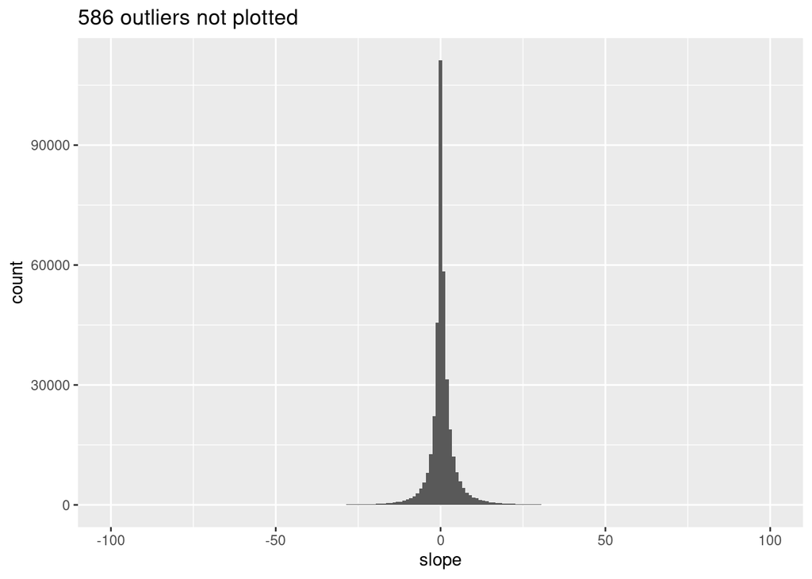

```r
plt = (ggplot (
      dv_cases_sensorized
    ) + geom_histogram (
      aes(slope),
      bins=200,
    ) + xlim (
      -plot_lim, plot_lim
    ) + ggtitle (
      sprintf('%d outliers not plotted', nrow(outliers))
    ))
plt
```

Surprisingly, there are quite a few negative slopes. Noise?

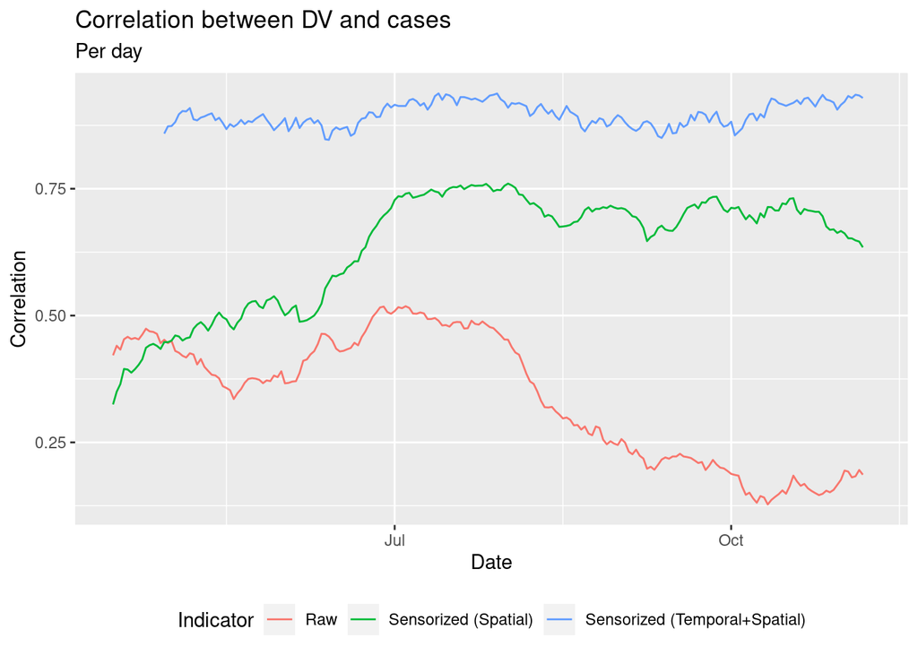

```r
df_sensorized = dv_cases_sensorized %>% transmute (
      geo_value=geo_value,
      signal='dv_sensorized',
      time_value=time_value,
      direction=NA,
      issue=lubridate::ymd('2020-11-01'),
      lag=NA,
      value=sensorized_value,
      stderr=NA,
      sample_size=NA,
      data_source='linear_sensorization',
    )
attributes(df_sensorized)$geo_type = 'county'
class(df_sensorized) = c("covidcast_signal", "data.frame")

df_cor_sensorized_dv = covidcast_cor(df_sensorized, df_cases,
                                     by='time_value', method='spearman')
df_cor = readRDS('results/01_df_cor.RDS')
df_cor_sensorized_dv$Indicator = 'Sensorized (Temporal+Spatial)'
df_cor = bind_rows(df_cor, df_cor_sensorized_dv)
plt = ggplot(df_cor, aes(x = time_value, y = value)) +
  geom_line(aes(color = Indicator)) +
  labs(title = sprintf("Correlation between %s and cases", "DV"),
       subtitle = "Per day",
       x = "Date", y = "Correlation") +
  theme(legend.position = "bottom")
plt
```

```r
sensorize_time_ranges = list(
      c(-14, -1),
      c(-14, -5),
      c(-21, -1),
      c(-21, -5))
sensorize_cors = vector('list', length(sensorize_time_ranges))
sensorize_cors[[1]] = df_cor_sensorized_dv %>% mutate(Indicator='Sensorized (TS, -14:-1)')

for (outer_idx in 2:length(sensorize_time_ranges)) {
  sensorize_llim = sensorize_time_ranges[[outer_idx]][1]
  sensorize_ulim = sensorize_time_ranges[[outer_idx]][2]

  min_sensorize_date = lubridate::ymd(start_day) - sensorize_llim
  max_sensorize_date = max(dv_cases$time_value)
  sensorize_date_offsets = 0:(max_sensorize_date-min_sensorize_date)

  joiner_df_list = vector('list', length(sensorize_date_offsets))
  for (idx in 1:length(sensorize_date_offsets)) {
    dt = sensorize_date_offsets[idx]
    sensorize_date = min_sensorize_date + dt
    joiner_df_list[[idx]] = tibble(
                      sensorize_date = sensorize_date,
                      time_value = sensorize_date + sensorize_llim:sensorize_ulim)
  }
  joiner_df = bind_rows(joiner_df_list)

  if (!PARCOMPUTE) {
    dv_sensorized_lm =  dv_cases %>% full_join(
          joiner_df,
          on='time_value',
        ) %>%  group_by (
          geo_value,
          sensorize_date,
        ) %>% group_modify (
          ~ broom::tidy(lm(cases_value ~ indicator_value, data = .x))
        ) %>% ungroup
  } else {
    dv_grouped_list =   dv_cases %>% full_join(
          joiner_df,
          on='time_value',
        ) %>%  group_by (
          geo_value,
          sensorize_date,
        ) %>% group_split
    dv_sensorized_lm = parallel::mclapply(dv_grouped_list, function(df) {
        broom::tidy(
          lm(cases_value ~ indicator_value, data = df)
        ) %>% mutate (
          geo_value = unique(df$geo_value),
          sensorize_date = unique(df$sensorize_date),
        )}, mc.cores = N_CORE) %>% bind_rows
  }
  dv_sensorized_wide = dv_sensorized_lm %>% select(
        geo_value,
        sensorize_date,
        term,
        estimate,
      ) %>% mutate (
        term = sapply(term, function(x) {ifelse(x=='(Intercept)',
                                                'intercept',
                                                'slope')}),
      ) %>% pivot_wider (
        id_cols = c(geo_value, sensorize_date),
        names_from=term,
        values_from=estimate,
      )
  dv_cases_sensorized = dv_cases %>% inner_join (
        dv_sensorized_wide,
        by=c('time_value'='sensorize_date',
             'geo_value'),
      ) %>% mutate (
        sensorized_value = intercept + indicator_value * slope,
      )
  df_sensorized = dv_cases_sensorized %>% transmute (
        geo_value=geo_value,
        signal='dv_sensorized',
        time_value=time_value,
        direction=NA,
        issue=lubridate::ymd('2020-11-01'),
        lag=NA,
        value=sensorized_value,
        stderr=NA,
        sample_size=NA,
        data_source='linear_sensorization',
      )
  attributes(df_sensorized)$geo_type = 'county'
  class(df_sensorized) = c("covidcast_signal", "data.frame")

  df_cor_sensorized_dv = covidcast_cor(df_sensorized, df_cases,
                                       by='time_value', method='spearman')
  df_cor_sensorized_dv$Indicator = sprintf('Sensorized (TS, %d:%d)',
                                           sensorize_llim,
                                           sensorize_ulim)
  sensorize_cors[[outer_idx]] = df_cor_sensorized_dv
}
```

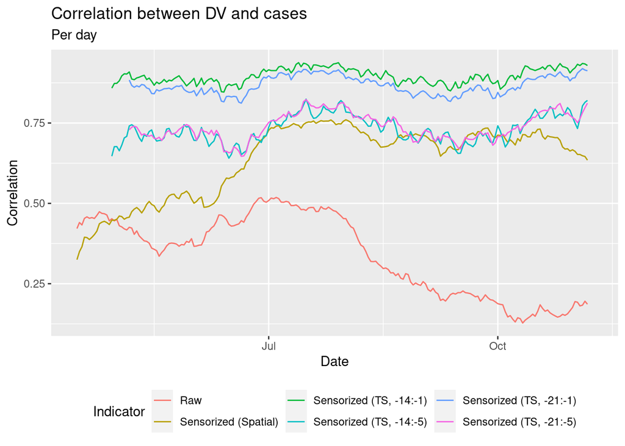

```r
saveRDS(sensorize_cors, 'results/02_sensorize_cors.RDS')

df_cor = readRDS('results/01_df_cor.RDS')
df_cor = bind_rows(df_cor, sensorize_cors)
plt = ggplot(df_cor, aes(x = time_value, y = value)) +
  geom_line(aes(color = Indicator)) +
  labs(title = sprintf("Correlation between %s and cases", "DV"),
       subtitle = "Per day",
       x = "Date", y = "Correlation") +
  theme(legend.position = "bottom")
plt
```